# Project: Investigate [No show appointments] Dataset

- Introduction
- Data Wrangling
- Exploratory Data Analysis
- Conclusions
- Bonus :Machine learning model

## Introduction

### Dataset Description

> This dataset collects information from 100k medical appointments in Brazil and is focused on the question of whether or not patients show up for their appointment,The original source of data can be found on [kaggle](https://www.kaggle.com/joniarroba/noshowappointments).

> A number of characteristics about the patient are included in each row such as :.
> - ‘ScheduledDay’ tells us on what day the patient set up their appointment.
> - ‘Neighborhood’ indicates the location of the hospital.
> - ‘Scholarship’ indicates whether or not the patient is enrolled in Brasilian welfare program Bolsa Família.
> - ‘SMS_received’ If patient receive a SMS or not .
> - ‘no_show’ It says ‘No’ if the patient showed up to their appointment, and ‘Yes’ if they did not show up.

### Question for Analysis

> 1. **what is the percentage of people who do show vs people who do not show ?**
> 2. **What factors are important for us to know in order to predict if a patient will show up for their scheduled appointment?**

```python
# installing sweetviz to do some interesting analysis to the data 😃
!pip install sweetviz
```

```
    100% |████████████████████████████████| 256kB 10.7MB/s ta 0:00:01
  Found existing installation: python-dateutil 2.6.1
    Uninstalling python-dateutil-2.6.1:
      Successfully uninstalled python-dateutil-2.6.1
```

```python
#importing packages
import numpy as np
import pandas as pd
import matplotlib.pyplot as plt
import sweetviz as sv
import seaborn as sns



% matplotlib inline
```

## Data Wrangling

> In this section of the report, we will load the data, check for cleanliness, trim and clean the dataset for analysis.

### General Properties

```python
# Load the data
df = pd.read_csv('Database_No_show_appointments/noshowappointments-kagglev2-may-2016.csv')
df.head()
```

|  | PatientId | AppointmentID | Gender | ScheduledDay | AppointmentDay | Age | Neighbourhood | Scholarship | Hipertension | Diabetes | Alcoholism | Handcap | SMS_received | No-show |
| --- | --- | --- | --- | --- | --- | --- | --- | --- | --- | --- | --- | --- | --- | --- |
| 0 | 2.987250e+13 | 5642903 | F | 2016-04-29T18:38:08Z | 2016-04-29T00:00:00Z | 62 | JARDIM DA PENHA | 0 | 1 | 0 | 0 | 0 | 0 | No |
| 1 | 5.589978e+14 | 5642503 | M | 2016-04-29T16:08:27Z | 2016-04-29T00:00:00Z | 56 | JARDIM DA PENHA | 0 | 0 | 0 | 0 | 0 | 0 | No |
| 2 | 4.262962e+12 | 5642549 | F | 2016-04-29T16:19:04Z | 2016-04-29T00:00:00Z | 62 | MATA DA PRAIA | 0 | 0 | 0 | 0 | 0 | 0 | No |
| 3 | 8.679512e+11 | 5642828 | F | 2016-04-29T17:29:31Z | 2016-04-29T00:00:00Z | 8 | PONTAL DE CAMBURI | 0 | 0 | 0 | 0 | 0 | 0 | No |
| 4 | 8.841186e+12 | 5642494 | F | 2016-04-29T16:07:23Z | 2016-04-29T00:00:00Z | 56 | JARDIM DA PENHA | 0 | 1 | 1 | 0 | 0 | 0 | No |

```python
for i,v in enumerate(df.columns):
    print(i,v)
```

```
0 PatientId
1 AppointmentID
2 Gender
3 ScheduledDay
4 AppointmentDay
5 Age
6 Neighbourhood
7 Scholarship
8 Hipertension
9 Diabetes
10 Alcoholism
11 Handcap
12 SMS_received
13 No-show
```

**Renaming :**

1. No-show column for better efficacy
2. correct the misspelling in the (Hipertension , Handcap)columns

```python
df.info()
```

```
<class 'pandas.core.frame.DataFrame'>
RangeIndex: 110527 entries, 0 to 110526
Data columns (total 14 columns):
 #   Column          Non-Null Count   Dtype
---  ------          --------------   -----
 0   PatientId       110527 non-null  float64
 1   AppointmentID   110527 non-null  int64
 2   Gender          110527 non-null  object
 3   ScheduledDay    110527 non-null  object
 4   AppointmentDay  110527 non-null  object
 5   Age             110527 non-null  int64
 6   Neighbourhood   110527 non-null  object
 7   Scholarship     110527 non-null  int64
 8   Hipertension    110527 non-null  int64
 9   Diabetes        110527 non-null  int64
 10  Alcoholism      110527 non-null  int64
 11  Handcap         110527 non-null  int64
 12  SMS_received    110527 non-null  int64
 13  No-show         110527 non-null  object
dtypes: float64(1), int64(8), object(5)
memory usage: 11.8+ MB
```

**It seems like there are 110527 rows in this data with 14 columns and no null values in it**

```python
df.duplicated().sum()
```

```
0
```

**Also there is no duplicated rows in the dataset**

```python
df.describe()
```

|  | PatientId | AppointmentID | Age | Scholarship | Hipertension | Diabetes | Alcoholism | Handcap | SMS_received |
| --- | --- | --- | --- | --- | --- | --- | --- | --- | --- |
| count | 1.105270e+05 | 1.105270e+05 | 110527.000000 | 110527.000000 | 110527.000000 | 110527.000000 | 110527.000000 | 110527.000000 | 110527.000000 |
| mean | 1.474963e+14 | 5.675305e+06 | 37.088874 | 0.098266 | 0.197246 | 0.071865 | 0.030400 | 0.022248 | 0.321026 |
| std | 2.560949e+14 | 7.129575e+04 | 23.110205 | 0.297675 | 0.397921 | 0.258265 | 0.171686 | 0.161543 | 0.466873 |
| min | 3.921784e+04 | 5.030230e+06 | -1.000000 | 0.000000 | 0.000000 | 0.000000 | 0.000000 | 0.000000 | 0.000000 |
| 25% | 4.172614e+12 | 5.640286e+06 | 18.000000 | 0.000000 | 0.000000 | 0.000000 | 0.000000 | 0.000000 | 0.000000 |
| 50% | 3.173184e+13 | 5.680573e+06 | 37.000000 | 0.000000 | 0.000000 | 0.000000 | 0.000000 | 0.000000 | 0.000000 |
| 75% | 9.439172e+13 | 5.725524e+06 | 55.000000 | 0.000000 | 0.000000 | 0.000000 | 0.000000 | 0.000000 | 1.000000 |
| max | 9.999816e+14 | 5.790484e+06 | 115.000000 | 1.000000 | 1.000000 | 1.000000 | 1.000000 | 4.000000 | 1.000000 |

**According to the last output age min value are negative which it might be a wrong input of data**

```python
# show the row of the negative age
df.query('Age == -1')
```

|  | PatientId | AppointmentID | Gender | ScheduledDay | AppointmentDay | Age | Neighbourhood | Scholarship | Hipertension | Diabetes | Alcoholism | Handcap | SMS_received | No-show |
| --- | --- | --- | --- | --- | --- | --- | --- | --- | --- | --- | --- | --- | --- | --- |
| 99832 | 4.659432e+14 | 5775010 | F | 2016-06-06T08:58:13Z | 2016-06-06T00:00:00Z | -1 | ROMÃO | 0 | 0 | 0 | 0 | 0 | 0 | No |

**This row will be dropped later in Data Cleaning step**

```python
df.nunique()
```

```
PatientId          62299
AppointmentID     110527
Gender                 2
ScheduledDay      103549
AppointmentDay        27
Age                  104
Neighbourhood         81
Scholarship            2
Hipertension           2
Diabetes               2
Alcoholism             2
Handcap                5
SMS_received           2
No-show                2
dtype: int64
```

**It seems that there are 5 unique values in Handicap column which it had to be only 2 value , that will need to be checked**

```python
df.Handcap.value_counts()
```

```
0    108286
1      2042
2       183
3        13
4         3
Name: Handcap, dtype: int64
```

**So according to this link [here](https://www.kaggle.com/joniarroba/noshowappointments) it not only show that there is Handicap or not but also show the level of it which is ok** .

### Fixes to make on dataset

1. changing columns name ( No-show to No_Show,Hipertension to Hypertension , Handcap to Handicap ) .
2. Delete the negative value of age.
3. converting gender and no_show columns to numeric value to appear when we run correlation on the data set .
4. Segment the age into groups.
5. Add a new column to the data containing the waiting time.
6. Extracting the handicap column to its levels.
7. Segment the waiting time into groups.

### Data Cleaning

#### 1.changing columns name ( No-show to No_Show,Hipertension to Hypertension , Handcap to Handicap ) .

```python
#1- Renaming No-show column for better efficacy /correct the misspelling in the (Hipertension , Handcap)columns:
df.rename(columns={'No-show': 'No_Show',
                   'Hipertension':'Hypertension',
                    'Handcap':'Handicap'} , inplace =True)
#checking the changes
for i,v in enumerate(df.columns):
    print(i,v)
```

```
0 PatientId
1 AppointmentID
2 Gender
3 ScheduledDay
4 AppointmentDay
5 Age
6 Neighbourhood
7 Scholarship
8 Hypertension
9 Diabetes
10 Alcoholism
11 Handicap
12 SMS_received
13 No_Show
```

#### 2.Delete the negative value of age.

```python
#2-Delete the negative value of age.
df.drop(index=99832, inplace = True)
#checking the changes
df.query('Age == -1')
```

|  | PatientId | AppointmentID | Gender | ScheduledDay | AppointmentDay | Age | Neighbourhood | Scholarship | Hypertension | Diabetes | Alcoholism | Handicap | SMS_received | No_Show |
| --- | --- | --- | --- | --- | --- | --- | --- | --- | --- | --- | --- | --- | --- | --- |

#### 3.converting gender and no_show columns to numeric value to appear when we run correlation on the data set .

```python
#3.1 converting gender to numeric value
gender = pd.get_dummies(df['Gender'],drop_first=True)
gender
```

|  | M |
| --- | --- |
| 0 | 0 |
| 1 | 1 |
| 2 | 0 |
| 3 | 0 |
| 4 | 0 |
| ... | ... |
| 110522 | 0 |
| 110523 | 0 |
| 110524 | 0 |
| 110525 | 0 |
| 110526 | 0 |

110526 rows × 1 columns

```python
#3.2 converting no_show to numeric value
no_show=pd.get_dummies(df['No_Show'],drop_first=True)
no_show
```

|  | Yes |
| --- | --- |
| 0 | 0 |
| 1 | 0 |
| 2 | 0 |
| 3 | 0 |
| 4 | 0 |
| ... | ... |
| 110522 | 0 |
| 110523 | 0 |
| 110524 | 0 |
| 110525 | 0 |
| 110526 | 0 |

110526 rows × 1 columns

```python
#3.3 adding the new colunms to the dataset
df['nugender'] =gender
df['nuno_show'] =no_show
df
```

|  | PatientId | AppointmentID | Gender | ScheduledDay | AppointmentDay | Age | Neighbourhood | Scholarship | Hypertension | Diabetes | Alcoholism | Handicap | SMS_received | No_Show | nugender | nuno_show |
| --- | --- | --- | --- | --- | --- | --- | --- | --- | --- | --- | --- | --- | --- | --- | --- | --- |
| 0 | 2.987250e+13 | 5642903 | F | 2016-04-29T18:38:08Z | 2016-04-29T00:00:00Z | 62 | JARDIM DA PENHA | 0 | 1 | 0 | 0 | 0 | 0 | No | 0 | 0 |
| 1 | 5.589978e+14 | 5642503 | M | 2016-04-29T16:08:27Z | 2016-04-29T00:00:00Z | 56 | JARDIM DA PENHA | 0 | 0 | 0 | 0 | 0 | 0 | No | 1 | 0 |
| 2 | 4.262962e+12 | 5642549 | F | 2016-04-29T16:19:04Z | 2016-04-29T00:00:00Z | 62 | MATA DA PRAIA | 0 | 0 | 0 | 0 | 0 | 0 | No | 0 | 0 |
| 3 | 8.679512e+11 | 5642828 | F | 2016-04-29T17:29:31Z | 2016-04-29T00:00:00Z | 8 | PONTAL DE CAMBURI | 0 | 0 | 0 | 0 | 0 | 0 | No | 0 | 0 |
| 4 | 8.841186e+12 | 5642494 | F | 2016-04-29T16:07:23Z | 2016-04-29T00:00:00Z | 56 | JARDIM DA PENHA | 0 | 1 | 1 | 0 | 0 | 0 | No | 0 | 0 |
| ... | ... | ... | ... | ... | ... | ... | ... | ... | ... | ... | ... | ... | ... | ... | ... | ... |
| 110522 | 2.572134e+12 | 5651768 | F | 2016-05-03T09:15:35Z | 2016-06-07T00:00:00Z | 56 | MARIA ORTIZ | 0 | 0 | 0 | 0 | 0 | 1 | No | 0 | 0 |
| 110523 | 3.596266e+12 | 5650093 | F | 2016-05-03T07:27:33Z | 2016-06-07T00:00:00Z | 51 | MARIA ORTIZ | 0 | 0 | 0 | 0 | 0 | 1 | No | 0 | 0 |
| 110524 | 1.557663e+13 | 5630692 | F | 2016-04-27T16:03:52Z | 2016-06-07T00:00:00Z | 21 | MARIA ORTIZ | 0 | 0 | 0 | 0 | 0 | 1 | No | 0 | 0 |
| 110525 | 9.213493e+13 | 5630323 | F | 2016-04-27T15:09:23Z | 2016-06-07T00:00:00Z | 38 | MARIA ORTIZ | 0 | 0 | 0 | 0 | 0 | 1 | No | 0 | 0 |
| 110526 | 3.775115e+14 | 5629448 | F | 2016-04-27T13:30:56Z | 2016-06-07T00:00:00Z | 54 | MARIA ORTIZ | 0 | 0 | 0 | 0 | 0 | 1 | No | 0 | 0 |

110526 rows × 16 columns

#### 4.Segment the age into groups.

```python
#4.Segment the age into groups
bin_edges = [ 0, 14 , 21 ,40 ,65,200 ]

bin_names = [ 'kids', 'young', 'adult', 'old','elders']
df['Age_Segment'] = pd.cut(df['Age'], bin_edges, labels=bin_names,include_lowest=True)
df.head()
```

|  | PatientId | AppointmentID | Gender | ScheduledDay | AppointmentDay | Age | Neighbourhood | Scholarship | Hypertension | Diabetes | Alcoholism | Handicap | SMS_received | No_Show | nugender | nuno_show | Age_Segment |
| --- | --- | --- | --- | --- | --- | --- | --- | --- | --- | --- | --- | --- | --- | --- | --- | --- | --- |
| 0 | 2.987250e+13 | 5642903 | F | 2016-04-29T18:38:08Z | 2016-04-29T00:00:00Z | 62 | JARDIM DA PENHA | 0 | 1 | 0 | 0 | 0 | 0 | No | 0 | 0 | old |
| 1 | 5.589978e+14 | 5642503 | M | 2016-04-29T16:08:27Z | 2016-04-29T00:00:00Z | 56 | JARDIM DA PENHA | 0 | 0 | 0 | 0 | 0 | 0 | No | 1 | 0 | old |
| 2 | 4.262962e+12 | 5642549 | F | 2016-04-29T16:19:04Z | 2016-04-29T00:00:00Z | 62 | MATA DA PRAIA | 0 | 0 | 0 | 0 | 0 | 0 | No | 0 | 0 | old |
| 3 | 8.679512e+11 | 5642828 | F | 2016-04-29T17:29:31Z | 2016-04-29T00:00:00Z | 8 | PONTAL DE CAMBURI | 0 | 0 | 0 | 0 | 0 | 0 | No | 0 | 0 | kids |
| 4 | 8.841186e+12 | 5642494 | F | 2016-04-29T16:07:23Z | 2016-04-29T00:00:00Z | 56 | JARDIM DA PENHA | 0 | 1 | 1 | 0 | 0 | 0 | No | 0 | 0 | old |

#### 5.Add a new column to the data containing the waiting time.

```python
#5.Extracting the date from ScheduledDay and AppointmentDay
df['ScheduledDay'] = pd.to_datetime(df['ScheduledDay']).dt.date
df['AppointmentDay'] = pd.to_datetime(df['AppointmentDay']).dt.date

#adding the waiting time column to the data as an integer
df['WaitingTime'] =(df['AppointmentDay']- df['ScheduledDay']).astype('timedelta64[D]').astype(int)
df.info()
```

```
<class 'pandas.core.frame.DataFrame'>
Int64Index: 110526 entries, 0 to 110526
Data columns (total 18 columns):
 #   Column          Non-Null Count   Dtype
---  ------          --------------   -----
 0   PatientId       110526 non-null  float64
 1   AppointmentID   110526 non-null  int64
 2   Gender          110526 non-null  object
 3   ScheduledDay    110526 non-null  object
 4   AppointmentDay  110526 non-null  object
 5   Age             110526 non-null  int64
 6   Neighbourhood   110526 non-null  object
 7   Scholarship     110526 non-null  int64
 8   Hypertension    110526 non-null  int64
 9   Diabetes        110526 non-null  int64
 10  Alcoholism      110526 non-null  int64
 11  Handicap        110526 non-null  int64
 12  SMS_received    110526 non-null  int64
 13  No_Show         110526 non-null  object
 14  nugender        110526 non-null  uint8
 15  nuno_show       110526 non-null  uint8
 16  Age_Segment     110526 non-null  category
 17  WaitingTime     110526 non-null  int64
dtypes: category(1), float64(1), int64(9), object(5), uint8(2)
memory usage: 13.8+ MB
```

```python
#5.1 checking for negative values
df.describe()
```

|  | PatientId | AppointmentID | Age | Scholarship | Hypertension | Diabetes | Alcoholism | Handicap | SMS_received | nugender | nuno_show | WaitingTime |
| --- | --- | --- | --- | --- | --- | --- | --- | --- | --- | --- | --- | --- |
| count | 1.105260e+05 | 1.105260e+05 | 110526.000000 | 110526.000000 | 110526.000000 | 110526.000000 | 110526.000000 | 110526.000000 | 110526.000000 | 110526.000000 | 110526.000000 | 110526.000000 |
| mean | 1.474934e+14 | 5.675304e+06 | 37.089219 | 0.098266 | 0.197248 | 0.071865 | 0.030400 | 0.022248 | 0.321029 | 0.350026 | 0.201934 | 10.183794 |
| std | 2.560943e+14 | 7.129544e+04 | 23.110026 | 0.297676 | 0.397923 | 0.258266 | 0.171686 | 0.161543 | 0.466874 | 0.476980 | 0.401445 | 15.255034 |
| min | 3.921784e+04 | 5.030230e+06 | 0.000000 | 0.000000 | 0.000000 | 0.000000 | 0.000000 | 0.000000 | 0.000000 | 0.000000 | 0.000000 | -6.000000 |
| 25% | 4.172536e+12 | 5.640285e+06 | 18.000000 | 0.000000 | 0.000000 | 0.000000 | 0.000000 | 0.000000 | 0.000000 | 0.000000 | 0.000000 | 0.000000 |
| 50% | 3.173184e+13 | 5.680572e+06 | 37.000000 | 0.000000 | 0.000000 | 0.000000 | 0.000000 | 0.000000 | 0.000000 | 0.000000 | 0.000000 | 4.000000 |
| 75% | 9.438963e+13 | 5.725523e+06 | 55.000000 | 0.000000 | 0.000000 | 0.000000 | 0.000000 | 0.000000 | 1.000000 | 1.000000 | 0.000000 | 15.000000 |
| max | 9.999816e+14 | 5.790484e+06 | 115.000000 | 1.000000 | 1.000000 | 1.000000 | 1.000000 | 4.000000 | 1.000000 | 1.000000 | 1.000000 | 179.000000 |

```python
#5.2 checking for negative values
df.query('WaitingTime  <0')
```

|  | PatientId | AppointmentID | Gender | ScheduledDay | AppointmentDay | Age | Neighbourhood | Scholarship | Hypertension | Diabetes | Alcoholism | Handicap | SMS_received | No_Show | nugender | nuno_show | Age_Segment | WaitingTime |
| --- | --- | --- | --- | --- | --- | --- | --- | --- | --- | --- | --- | --- | --- | --- | --- | --- | --- | --- |
| 27033 | 7.839273e+12 | 5679978 | M | 2016-05-10 | 2016-05-09 | 38 | RESISTÊNCIA | 0 | 0 | 0 | 0 | 1 | 0 | Yes | 1 | 1 | adult | -1 |
| 55226 | 7.896294e+12 | 5715660 | F | 2016-05-18 | 2016-05-17 | 19 | SANTO ANTÔNIO | 0 | 0 | 0 | 0 | 1 | 0 | Yes | 0 | 1 | young | -1 |
| 64175 | 2.425226e+13 | 5664962 | F | 2016-05-05 | 2016-05-04 | 22 | CONSOLAÇÃO | 0 | 0 | 0 | 0 | 0 | 0 | Yes | 0 | 1 | adult | -1 |
| 71533 | 9.982316e+14 | 5686628 | F | 2016-05-11 | 2016-05-05 | 81 | SANTO ANTÔNIO | 0 | 0 | 0 | 0 | 0 | 0 | Yes | 0 | 1 | elders | -6 |
| 72362 | 3.787482e+12 | 5655637 | M | 2016-05-04 | 2016-05-03 | 7 | TABUAZEIRO | 0 | 0 | 0 | 0 | 0 | 0 | Yes | 1 | 1 | kids | -1 |

```python
#5.3 droping the negative values
df = df[df['WaitingTime'] >= 0]
df.query('WaitingTime  <0')
```

|  | PatientId | AppointmentID | Gender | ScheduledDay | AppointmentDay | Age | Neighbourhood | Scholarship | Hypertension | Diabetes | Alcoholism | Handicap | SMS_received | No_Show | nugender | nuno_show | Age_Segment | WaitingTime |
| --- | --- | --- | --- | --- | --- | --- | --- | --- | --- | --- | --- | --- | --- | --- | --- | --- | --- | --- |

#### 6.Extracting the handicap column to its levels.

```python
#6.Extracting the handicap column to its levels.
Handicap=pd.get_dummies(df['Handicap'],prefix='Handicap')
Handicap
```

|  | Handicap_0 | Handicap_1 | Handicap_2 | Handicap_3 | Handicap_4 |
| --- | --- | --- | --- | --- | --- |
| 0 | 1 | 0 | 0 | 0 | 0 |
| 1 | 1 | 0 | 0 | 0 | 0 |
| 2 | 1 | 0 | 0 | 0 | 0 |
| 3 | 1 | 0 | 0 | 0 | 0 |
| 4 | 1 | 0 | 0 | 0 | 0 |
| ... | ... | ... | ... | ... | ... |
| 110522 | 1 | 0 | 0 | 0 | 0 |
| 110523 | 1 | 0 | 0 | 0 | 0 |
| 110524 | 1 | 0 | 0 | 0 | 0 |
| 110525 | 1 | 0 | 0 | 0 | 0 |
| 110526 | 1 | 0 | 0 | 0 | 0 |

110521 rows × 5 columns

```python
#6 adding the new colunms to the data
df=pd.concat([df, Handicap],axis=1)
df.head()
```

|  | PatientId | AppointmentID | Gender | ScheduledDay | AppointmentDay | Age | Neighbourhood | Scholarship | Hypertension | Diabetes | ... | No_Show | nugender | nuno_show | Age_Segment | WaitingTime | Handicap_0 | Handicap_1 | Handicap_2 | Handicap_3 | Handicap_4 |
| --- | --- | --- | --- | --- | --- | --- | --- | --- | --- | --- | --- | --- | --- | --- | --- | --- | --- | --- | --- | --- | --- |
| 0 | 2.987250e+13 | 5642903 | F | 2016-04-29 | 2016-04-29 | 62 | JARDIM DA PENHA | 0 | 1 | 0 | ... | No | 0 | 0 | old | 0 | 1 | 0 | 0 | 0 | 0 |
| 1 | 5.589978e+14 | 5642503 | M | 2016-04-29 | 2016-04-29 | 56 | JARDIM DA PENHA | 0 | 0 | 0 | ... | No | 1 | 0 | old | 0 | 1 | 0 | 0 | 0 | 0 |
| 2 | 4.262962e+12 | 5642549 | F | 2016-04-29 | 2016-04-29 | 62 | MATA DA PRAIA | 0 | 0 | 0 | ... | No | 0 | 0 | old | 0 | 1 | 0 | 0 | 0 | 0 |
| 3 | 8.679512e+11 | 5642828 | F | 2016-04-29 | 2016-04-29 | 8 | PONTAL DE CAMBURI | 0 | 0 | 0 | ... | No | 0 | 0 | kids | 0 | 1 | 0 | 0 | 0 | 0 |
| 4 | 8.841186e+12 | 5642494 | F | 2016-04-29 | 2016-04-29 | 56 | JARDIM DA PENHA | 0 | 1 | 1 | ... | No | 0 | 0 | old | 0 | 1 | 0 | 0 | 0 | 0 |

5 rows × 23 columns

#### 7.Segment the waiting time into groups.

```python
#7.Segment the age into groups
bin_edges = [ 0,1,30,60,90,120,150,180 ]

bin_names = ['same day','1 month','2 month','3 month','4 month','5 month','6 month']
df['WT_Segment'] = pd.cut(df.WaitingTime, bin_edges, labels=bin_names,include_lowest=True)
df.head()
```

|  | PatientId | AppointmentID | Gender | ScheduledDay | AppointmentDay | Age | Neighbourhood | Scholarship | Hypertension | Diabetes | ... | nugender | nuno_show | Age_Segment | WaitingTime | Handicap_0 | Handicap_1 | Handicap_2 | Handicap_3 | Handicap_4 | WT_Segment |
| --- | --- | --- | --- | --- | --- | --- | --- | --- | --- | --- | --- | --- | --- | --- | --- | --- | --- | --- | --- | --- | --- |
| 0 | 2.987250e+13 | 5642903 | F | 2016-04-29 | 2016-04-29 | 62 | JARDIM DA PENHA | 0 | 1 | 0 | ... | 0 | 0 | old | 0 | 1 | 0 | 0 | 0 | 0 | same day |
| 1 | 5.589978e+14 | 5642503 | M | 2016-04-29 | 2016-04-29 | 56 | JARDIM DA PENHA | 0 | 0 | 0 | ... | 1 | 0 | old | 0 | 1 | 0 | 0 | 0 | 0 | same day |
| 2 | 4.262962e+12 | 5642549 | F | 2016-04-29 | 2016-04-29 | 62 | MATA DA PRAIA | 0 | 0 | 0 | ... | 0 | 0 | old | 0 | 1 | 0 | 0 | 0 | 0 | same day |
| 3 | 8.679512e+11 | 5642828 | F | 2016-04-29 | 2016-04-29 | 8 | PONTAL DE CAMBURI | 0 | 0 | 0 | ... | 0 | 0 | kids | 0 | 1 | 0 | 0 | 0 | 0 | same day |
| 4 | 8.841186e+12 | 5642494 | F | 2016-04-29 | 2016-04-29 | 56 | JARDIM DA PENHA | 0 | 1 | 1 | ... | 0 | 0 | old | 0 | 1 | 0 | 0 | 0 | 0 | same day |

5 rows × 24 columns

## Exploratory Data Analysis

### Getting over-view about the data

```python
df.corr().nuno_show
```

```
PatientId       -0.001477
AppointmentID   -0.162619
Age             -0.060320
Scholarship      0.029166
Hypertension    -0.035662
Diabetes        -0.015158
Alcoholism      -0.000181
Handicap        -0.006290
SMS_received     0.126502
nugender        -0.004132
nuno_show        1.000000
WaitingTime      0.186320
Handicap_0       0.007528
Handicap_1      -0.008017
Handicap_2       0.000029
Handicap_3       0.000780
Handicap_4       0.001706
Name: nuno_show, dtype: float64
```

**As it show above most of the values are nearly 0 which mean most of the data on the columns has no effect on making someone show or not show at his/her appointment, but still there is something interesting about people who received SMS( correlation is positive with people who do not show at their appointment)**

```python
# analyzing data to get over-view
df1 = df.drop('WT_Segment', axis =1)
my_report = sv.analyze(df1)
my_report.show_notebook(filepath='SWEETVIZ_REPORT.html')
```

[interactive chart not shown]

```
Report 'SWEETVIZ_REPORT.html' was saved to storage.
```

### Preparing graphs :

```python
# Pie Chart
def pac_man(Chart_values, colour, legend, title, angle ):
    """
    Creates a pie chart

    Args:
        Chart_values: the values inside the pie chart
        colour: colours of the different values
        legend: legend of the chart
        title: the title for the chart
        angle: the start-angle

    Returns:
        The chart graph
    """
    plt.pie(Chart_values, explode=(0, 0.1), colors =colour ,shadow=True, autopct='%.1f%%', startangle=angle)
    plt.axis('scaled')
    plt.legend(legend)
    plt.title(title)
    return plt.show()


# Bar chart 1
def kitkat_bar(x_axis_values , y_axis_values, color, title, xlabel, ylabel):
    """
    Creates a Bar chart with single value on x axis

    Args:
        x_axis_values : represent the values on x axis
        y_axis_values:  represent the values on y axis
        color: colours of the different values
        title: the title for the chart
        xlabel: name of the x axis
        ylabel: name of the y axis

    Returns:
        The chart graph
    """
    plt.figure(figsize=(4, 4))
    plt.title(title, fontsize=15)
    plt.xlabel(xlabel)
    plt.ylabel(ylabel)
    plt.bar(x_axis_values, y_axis_values, color=color, width=0.3, )
    return plt.show()


# Bar chart 2
def twix_bar(Chart_values, color, xticklabels, xlabel, ylabel, legend, title):
    """
    Creates a Bar chart with multi value on x axis

    Args:
        Chart_values: The values inside the bar chart
        color: colours of the different values
        xticklabels: The names of the different values of the x axis
        xlabel: represent the values on x axis
        ylabel: represent the values on y axis
        legend: legend of the chart
        title: the title for the chart

    Returns:
        The chart graph
    """
    ax = Chart_values.plot.bar(figsize=(5, 5), color=color)
    ax.set_xticklabels(xticklabels, fontsize=15, rotation=0)
    ax.set_ylabel(ylabel)
    ax.set_xlabel(xlabel)
    ax.legend(legend)
    ax.set_title(title)
    return plt.show()


# Line chart
def line(Chart_values, color, xlabel, ylabel, legend, title):
    """
    Creats a line chart

    Args:
        Chart_values: The values inside the line chart
        color: colours of the different values
        xlabel: represent the values on x axis
        ylabel: represent the values on y axis
        legend: legend of the chart
        title: the title for the chart

    Returns:
        The chart graph
    """
    ax = Chart_values.plot(figsize=(5, 5), color=color)
    ax.legend(legend)
    ax.set_title(title)
    ax.set_ylabel(ylabel)
    ax.set_xlabel(xlabel)
    return plt.show()
```

### 1.what is the percentage of people who did show vs people who did not show ?

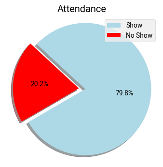

```python
# Creating a pie chart .
pac_man(df.No_Show.value_counts(),['lightblue','r'],['Show', 'No Show'],'Attendance',210)
```

**According to the pie chart above, The percentage of people who did show up was 79.8% and who didn't was 20.2%.**

### 2.What factors are important for us to know in order to predict if a patient will show up for their scheduled appointment?

```python
plt.style.use('bmh')
```

### A:Gender

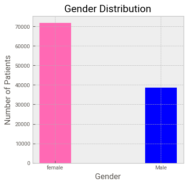

```
F    71836
M    38685
Name: Gender, dtype: int64
```

```python
# Gender Distribution
kitkat_bar(['female','Male'], df.Gender.value_counts(), ["hotpink",'Blue'], 'Gender Distribution','Gender','Number of Patients')

df.Gender.value_counts()
```

```python
# Male vs Female show up Numbers
pd.crosstab(df['Gender'], df['No_Show'])
```

| No_Show Gender | No | Yes |
| --- | --- | --- |
| F | 57245 | 14591 |
| M | 30962 | 7723 |

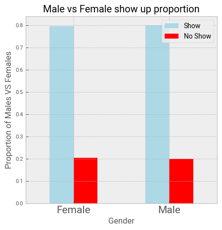

| No_Show Gender | No | Yes |
| --- | --- | --- |
| F | 0.796885 | 0.203115 |
| M | 0.800362 | 0.199638 |

```python
# Male vs Female show up proportion
x= pd.crosstab(df['Gender'], df['No_Show'],normalize = 'index')

twix_bar( x , ['lightblue','r'], ['Female','Male'], 'Gender', 'Proportion of Males VS Females', ['Show', 'No Show'],
         'Male vs Female show up proportion')
x
```

**As the bar chart shows the proportion of males was a little bit higher than the female's proportion**

### B:Age

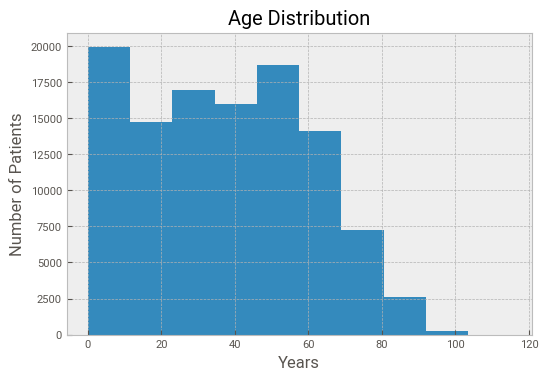

```python
#A histogram visual the age distribution across the dataset
plt.hist(df.Age)
plt.title('Age Distribution')
plt.xlabel('Years')
plt.ylabel('Number of Patients');
```

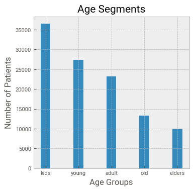

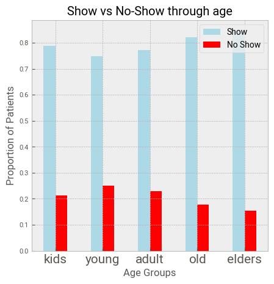

| No_Show Age_Segment | No | Yes |
| --- | --- | --- |
| kids | 0.788227 | 0.211773 |
| young | 0.748656 | 0.251344 |
| adult | 0.771046 | 0.228954 |
| old | 0.821274 | 0.178726 |
| elders | 0.844737 | 0.155263 |

```python
x= [ 'kids', 'young', 'adult', 'old','elders']
y= df.Age_Segment.value_counts()
kitkat_bar(x, y, None , 'Age Segments','Age Groups','Number of Patients')



z = pd.crosstab(df['Age_Segment'], df['No_Show'], normalize = 'index')

twix_bar( z , ['lightblue','r'],x, 'Age Groups', 'Proportion of Patients', ['Show', 'No Show'], 'Show vs No-Show through age')

z
```

### C:Scholarship

> ‘Scholarship’ indicates whether or not the patient is enrolled in Brasilian welfare program Bolsa Família,more informatithion can be found [here](https://en.wikipedia.org/wiki/Bolsa_Fam%C3%ADlia)

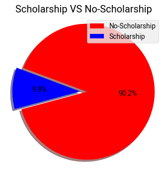

```python
pac_man(df.Scholarship.value_counts(), ['r','blue'], ['No-Scholarship', 'Scholarship'], 'Scholarship VS No-Scholarship', 195 )
```

**As it shows it seems like 9.8% have scholarship and 90.2% of patients have no No-Scholarship**

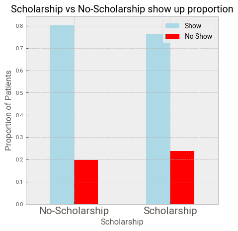

| No_Show Scholarship | No | Yes |
| --- | --- | --- |
| 0 | 0.801967 | 0.198033 |
| 1 | 0.762637 | 0.237363 |

```python
x = pd.crosstab(df['Scholarship'], df['No_Show'],normalize = 'index')

twix_bar( x , ['lightblue','r'], ['No-Scholarship','Scholarship'], 'Scholarship', 'Proportion of Patients', ['Show', 'No Show'],
         'Scholarship vs No-Scholarship show up proportion')

x
```

**It seems like patients who have no scholarship tend to have a higher rate on show up than patients who have a scholarship**

### D:SMS_received

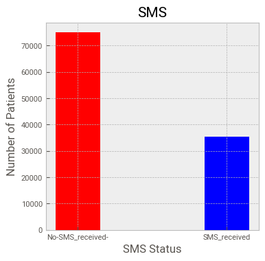

```
0    75039
1    35482
Name: SMS_received, dtype: int64
```

```python
kitkat_bar(['No-SMS_received-','SMS_received'], df.SMS_received.value_counts(), ["red",'Blue'], 'SMS','SMS Status',
           'Number of Patients')

df.SMS_received.value_counts()
```

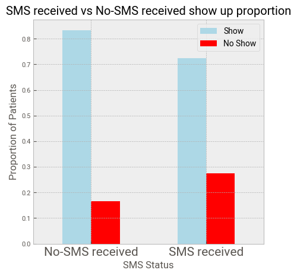

| No_Show SMS_received | No | Yes |
| --- | --- | --- |
| 0 | 0.833020 | 0.166980 |
| 1 | 0.724255 | 0.275745 |

```python
x = pd.crosstab(df['SMS_received'], df['No_Show'], normalize = 'index')

twix_bar( x , ['lightblue','r'], ['No-SMS received','SMS received'], 'SMS Status', 'Proportion of Patients',
         ['Show', 'No Show'], 'SMS received vs No-SMS received show up proportion')


x
```

**Surprisingly, patients proportions who didn't receive SMS have a higher show-up rate.**

### E: Wating time

| No_Show WT_Segment | No | Yes |
| --- | --- | --- |
| same day | 0.933638 | 0.066362 |
| 1 month | 0.716435 | 0.283565 |
| 2 month | 0.658457 | 0.341543 |
| 3 month | 0.712460 | 0.287540 |
| 4 month | 0.795455 | 0.204545 |
| 5 month | 0.620690 | 0.379310 |
| 6 month | 0.678571 | 0.321429 |

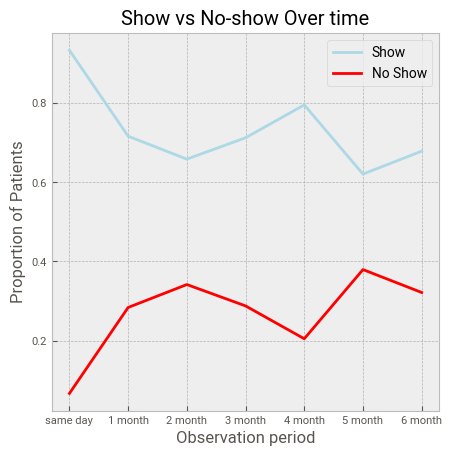

```python
x = pd.crosstab(df['WT_Segment'], df['No_Show'],normalize = 'index' )

line( x , ['lightblue','r'], 'Observation period', 'Proportion of Patients', ['Show', 'No Show'], 'Show vs No-show Over time')

x
```

## Conclusions

### Limitations

- The dataset's observation period was too short .
- Data set should have more data such as illness.
- Location of the clinic vs the neighborhood location.
- Advanced time serises analyis can be done on waiting time .
- Advanced statistical analysis can be on the data set, not only on factories that affect show and no show rate but on other things such as waiting time vs SMS received and more data should be given on when SMS is being sent and what the conditions to sent a SMS.

## Bonus :Machine learning model

> Here we going to do a simple Machine learning approach

### Spliting the data-set

we going to split our data to 2 main parts X and y :

> X will carry all the inputs that may affect the output which in this case it is y,

> in simple speaking we X is the input and y will be the result we want.

```python
X  = df.iloc[:, np.r_[5, 7:11,12,14,17:23]]
y = df['nuno_show']
y
```

```
0         0
1         0
2         0
3         0
4         0
         ..
110522    0
110523    0
110524    0
110525    0
110526    0
Name: nuno_show, Length: 110521, dtype: uint8
```

**Here we will divide :**

> 1-X to X_train and X_test ( X_train will be 70% of X , X_test will be 30 % of X)

> 2-y to x_train and y_test ( y_train will be 70% of y , y_test will be 30 % of y)

```python
from sklearn.model_selection import train_test_split
```

```python
X_train, X_test, y_train, y_test = train_test_split(X , y, test_size=0.30, random_state=42)
y_train
```

```
24404     0
4800      1
65322     0
42536     0
18424     0
         ..
76825     1
110274    0
103700    1
860       0
15795     0
Name: nuno_show, Length: 77364, dtype: uint8
```

### building the models

> Here we will train our models: we will give the machine X_train as input and x_train as the result of X_train then we will try to make the models get a predicted value of y_test using X_test

```python
from sklearn.linear_model import LogisticRegression
from sklearn.ensemble import GradientBoostingClassifier
```

```python
model1 = LogisticRegression(max_iter=4000)
```

```python
model1.fit(X_train,y_train)
```

```
LogisticRegression(C=1.0, class_weight=None, dual=False, fit_intercept=True,
          intercept_scaling=1, max_iter=4000, multi_class='ovr', n_jobs=1,
          penalty='l2', random_state=None, solver='liblinear', tol=0.0001,
          verbose=0, warm_start=False)
```

```python
y_pred = model1.predict(X_test)
y_pred
```

```
array([0, 0, 0, ..., 0, 0, 0], dtype=uint8)
```

### Evaluation the models

> Here we will compare the machine result (y_pred ) with the actual result (y_test ) and see how the accuracy of the machine

```python
from sklearn.metrics import classification_report
```

```python
print(classification_report(y_test,y_pred))
```

```
             precision    recall  f1-score   support

          0       0.80      0.99      0.89     26475
          1       0.31      0.01      0.03      6682

avg / total       0.70      0.79      0.71     33157
```

```python
model2 = GradientBoostingClassifier()
```

```python
model2.fit(X_train, y_train)
```

```
GradientBoostingClassifier(criterion='friedman_mse', init=None,
              learning_rate=0.1, loss='deviance', max_depth=3,
              max_features=None, max_leaf_nodes=None,
              min_impurity_decrease=0.0, min_impurity_split=None,
              min_samples_leaf=1, min_samples_split=2,
              min_weight_fraction_leaf=0.0, n_estimators=100,
              presort='auto', random_state=None, subsample=1.0, verbose=0,
              warm_start=False)
```

```python
y_pred2 = model2.predict(X_test)
y_pred2
```

```
array([0, 0, 0, ..., 0, 0, 0], dtype=uint8)
```

```python
print(classification_report(y_test,y_pred2))
```

```
             precision    recall  f1-score   support

          0       0.80      1.00      0.89     26475
          1       0.49      0.01      0.01      6682

avg / total       0.74      0.80      0.71     33157
```

# Thank you , take care and see you soon

```python
#Import this file to HTML file.
from subprocess import call
call(['python', '-m', 'nbconvert', 'Investigate_a_Dataset_No_show_appointments.ipynb'])
```

```
0
```